# Battle of Cities in Germany - Which city in Germany we should choose to open our next bubble tea store

1. Introduction and Business Problem
2. Data Section
3. Methodology
4. Results
5. Discussion Section
6. Conclusion
7. Appendix

## Introduction / Business Problem

The so-called "bubble tea" is gaining increasing popularity outside each asia in recent years. Originally the "bubble" in the name refers to the bubble resulted from blending black tea with ice and fruit syrups, but somehow it is mostly mistakenly understood as the tapioca or bobas as the topping in the drink.

In Düsseldorf, Germany we have been running two commercially successful bubble tea stores for more than ten years. Düsseldorf is one of the biggest city of Germany and the japanese center amongst german cities and is hosting a large varieties of japanese companies, intitutions and a big japanese population. In the recent decade Chinese and Koreans have been inhabitating this german city with great atmosphere of asian culture. That explains partially the reason why our bubble tea stores are popular. Meanwhile it should be pointed out that the majority of customers are still german, mostly young generation of german and children.

Now we have decided to expand our brand and to open more stores in Germany. All cities in Germany are under consideration. The core problem is to find a list of potential cities to open our store, where the business is more likely to succeed as we have experienced in Düsseldorf. We want to use data science to get a list to help our site search.

## Data Section

To utilize the foursquare api on venues we need the information of longitude and latitude of major german cities. We adopt the following list of major german cities which encompasses all candidates in our understanding. https://www.latlong.net/category/cities-83-15.html

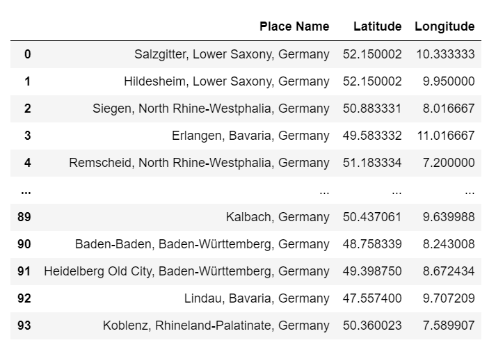

A full despcription of the data we could get can be read in https://developer.foursquare.com/docs/places-database/details/.

## Methodology

We scrape the data from the following list. https://www.latlong.net/category/cities-83-15.html

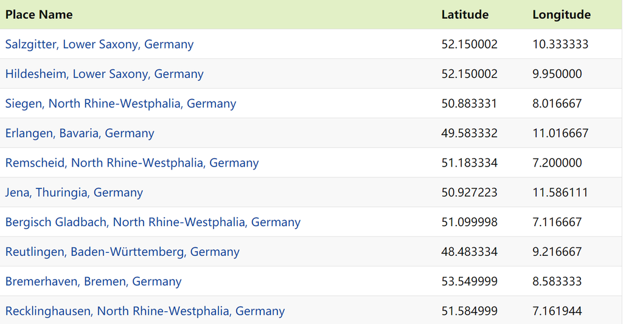

we get the following data frame

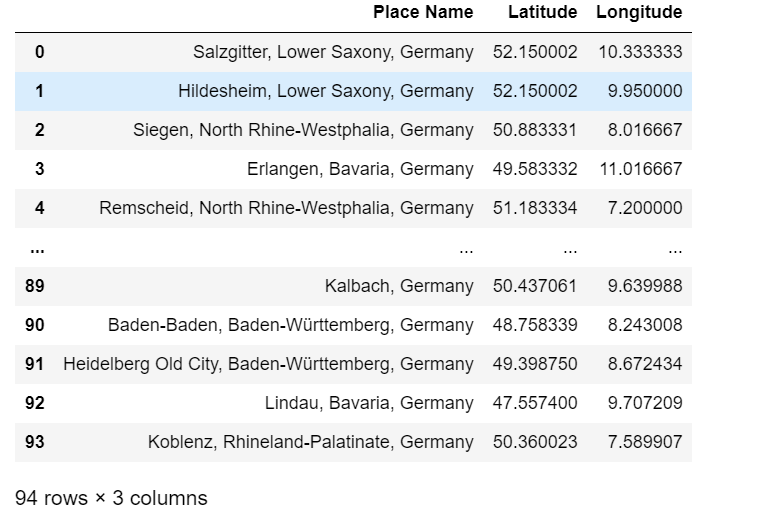

We use **FourSquare** to get the venue information. In particular we regard an area of radius 5 km as the core city part of our investigation, which would also be the range where we select our site.

The venue information will encompass the top venue.For instance the following is the top 30 venues in Düsseldorf. As one can see, many asian elements are involved.

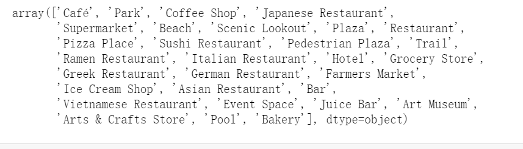

So most popular venues reflect the interests, flavors, tendancy. We use k-mean clustering to automatically categorize the major towns in germany. To get a short list, k is chosen to be 23 here. We get a clustering of german major cities.

We use folium to visulize the cities in a map.

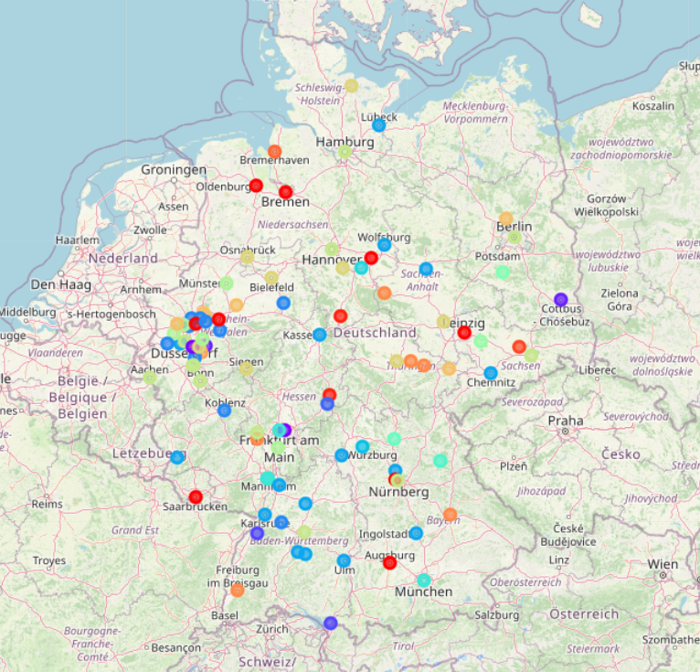

In particular the group which includes Düsseldorf is

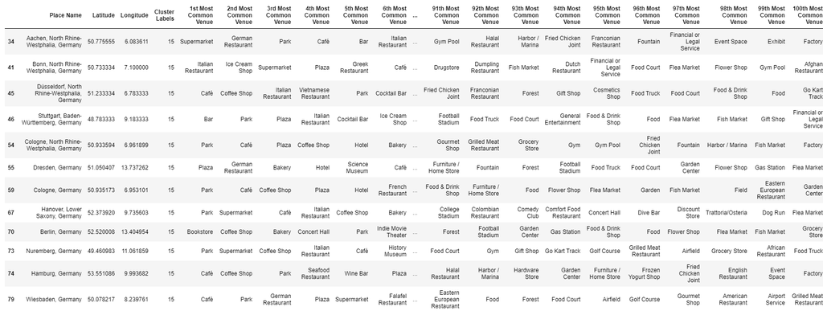

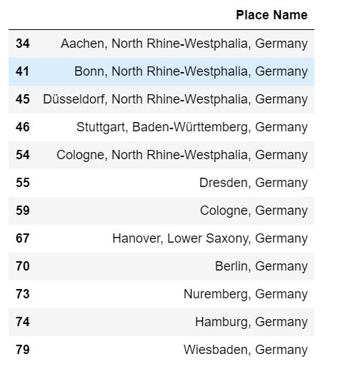

So we end up with a short list of german cities where we can potentially open a new store, since people live there or visit there have similar tendancy as in Düsseldorf.

## Result

The major international cities like Berlin, Hamburg are listed. These cities obviously serve as international connection point and hosts a large number of international institutions, companies, tourists groups, also universities. Our data analysis by clustering confirms its open culture.

Cities like Aachen, Bonn, Cologne are in the same Rheinland area as Düsseldorf. These cities are also commericially active cities which host famous universities in Germany, which accounts for the international elements of the cities.

Dresden, Hannover, Stuttgart and Wiesbaden are all capitals of the respective federal states, which are comparatively economically well performing states. Their appearance on the lists are all comprehensible.

In the contrast the bavarian metropolitian Munich, which is regarded as the wealthiest city, is not listed.

## Discussion section

We have considered purely in terms of venues. What other elements could be important to our consideration? for example:

1. GDP per capital
2. the number of foreigners
3. the existing numbers of potential competitors
4. distance to the headquarter in Düsseldorf ... How to encorporate these elements into the data set. For example which kinds of stores should be considered as competitors and which should not be. For example is coffee shop to be thought as competitors?

Does the number of top venues also affect the results? Does the choice of the number of clusters merely narrow down the number of each cluster group or does it affects the structure of the clustering?

To further the investigation, how should we find the right neighborhood, even the street to open our new store?

These questions are all topics one can dig deeper.

## Conclusion

Third, capitals of several economic strong federal states, like Hannover, Stuttgart, Wiesbaden, Dresden are also listed as the potentials.

Last but not least, there are also famous cities, which might be considered more traditional, are not particularly suitable for an asian shop, so delivers our analysis this information.

## Appendix

One can find the Jupyter notebook with the code in https://github.com/Hyperboloiz/battlegermany/blob/main/code.ipynb